# ISBN: 978-958-5153-36-3-G11-2024-1 Pregunta 11

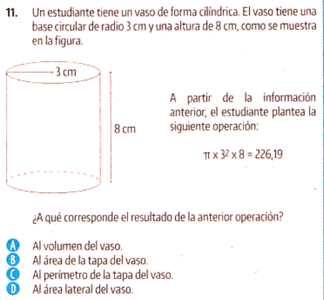

La operación dada es:

$$\pi \times 3^2 \times 8 \approx 226.19$$

Se nos proporciona un vaso cilíndrico con un radio de 3 cm y una altura de 8 cm. El problema nos pide identificar a qué corresponde el resultado de la operación entre las siguientes opciones:

- Al volumen del vaso.
- Al área de la tapa del vaso.
- Al perímetro de la tapa del vaso.
- Al área lateral del vaso.

### Paso a paso:

1. **Volumen del vaso**:  
   El volumen $V$ de un cilindro se calcula mediante la fórmula:

   $$V = \pi r^2 h$$

   Donde $r = 3 \, \text{cm}$ y $h = 8 \, \text{cm}$. Por lo tanto:

   $$V = \pi \times 3^2 \times 8 = 72\pi \, \text{cm}^3$$

   Usando $\pi \approx 3.1416$:

   $$72 \times 3.1416 \approx 226.19 \, \text{cm}^3$$

   Este valor coincide con el resultado de la operación.
2. **Área de la tapa del vaso**:  
   El área de la base circular es:

   $$A = \pi r^2 = \pi \times 3^2 = 9\pi \, \text{cm}^2 \approx 28.27 \,
   \text{cm}^2$$

   No coincide con 226.19.
3. **Perímetro de la tapa del vaso**:  
   El perímetro de la base circular es:

   $$P = 2\pi r = 2\pi \times 3 = 6\pi \, \text{cm} \approx 18.85 \,
   \text{cm}$$

   No coincide con 226.19.
4. **Área lateral del vaso**:  
   El área lateral se calcula con:

   $$A_{\text{lateral}} = 2\pi r h = 2\pi \times 3 \times 8 = 48\pi \,
   \text{cm}^2 \approx 150.796 \, \text{cm}^2$$

   No coincide con 226.19.

### Conclusión:

La operación $\pi \times 3^2 \times 8 = 226.19$ corresponde al **volumen del vaso**, ya que el cálculo del volumen con las dimensiones dadas coincide con el valor obtenido.

### Opción correcta:

**A). Al volumen del vaso.**

# Análisis de la Pregunta según SABER 11 ICFES

## Características de la Pregunta

- **Nivel de Desempeño**: Avanzado. Puntaje 4/4.  
  *Justificación*: Requiere análisis y comprensión de múltiples conceptos geométricos y capacidad para discriminar entre diferentes medidas.
- **Competencia Dominante**: Razonamiento (60%), Resolución de problemas (40%)  
  *Justificación*: Requiere analizar diferentes posibilidades y aplicar conceptos geométricos para determinar la medida correcta.
- **Afirmación**: Comprende y manipula información cuantitativa y geométrica representada en distintos formatos.
- **Componente**: Geométrico-métrico  
  *Justificación*: Involucra cálculos y conceptos relacionados con medidas geométricas tridimensionales.
- **Aprendizajes**:
  - Calcula e interpreta medidas de superficies y volúmenes
  - Diferencia entre distintos tipos de medidas geométricas
- **Evidencias**:
  - “Estima, calcula y compara volúmenes a partir de las relaciones entre las aristas de un prisma o de otros sólidos”
  - “Interpreta las expresiones algebraicas que representan el volumen y el área cuando sus dimensiones varían”
- **Contenidos Matemáticos Curriculares**:
  - Geometría espacial
  - Medición de volúmenes
  - Cilindros y sus propiedades
- **¿Genérico o No Genérico?**: No Genérico *Justificación*: Evalúa conocimientos específicos de geometría espacial y medición.
- **Estándar asociado**: “Utiliza y explica diferentes estrategias para encontrar el volumen de objetos regulares e irregulares en la solución de problemas en las matemáticas y en otras ciencias.”

## Análisis Detallado

### ¿Qué evalúa?

Evalúa la capacidad del estudiante para: 1. Identificar las diferentes medidas posibles en un cilindro 2. Reconocer y aplicar fórmulas geométricas 3. Interpretar resultados numéricos en contexto geométrico

### Ampliación de la Respuesta Correcta

La opción A es correcta porque:

1. El volumen de un cilindro se calcula con la fórmula V = πr²h
2. Sustituyendo los valores:
   - r = 3 cm
   - h = 8 cm V = π(3)²(8) = π(9)(8) = 72π ≈ 226.19 cm³

### Justificación de las Opciones Incorrectas

**Opción B (Área de la tapa)**

- Fórmula: A = πr²
- Cálculo: A = π(3)² = 9π ≈ 28.27 cm²
- *Distractor*: Confunde el área de la base con el volumen total

**Opción C (Perímetro de la tapa)**

- Fórmula: P = 2πr
- Cálculo: P = 2π(3) = 6π ≈ 18.85 cm
- *Distractor*: Confunde una medida lineal con una cúbica

**Opción D (Área lateral)**

- Fórmula: AL = 2πrh
- Cálculo: AL = 2π(3)(8) = 48π ≈ 150.796 cm²
- *Distractor*: Confunde una medida de superficie con una de volumen